# Machine Learning

Jose Rios

May 29, 2018

## Project

In this project, the goal is to use data from accelerometers on the belt, forearm, arm, and dumbbell of 6 participants in an experiment carried out by a group of enthusiasts who took measurements about themselves regularly to improve their health, to find patterns in their behavior, or because they are tech geeks. They were asked to perform barbell lifts correctly and incorrectly in 5 different ways.

The data is divided into two sets: a training and a testing set. They come from the Pontifical Catholic University-Rio de Janeiro in Brazil (http://groupware.les.inf.puc-rio.br/har).

First let us know what’s in each file.

```r
library("caret")
set.seed(33873)
training<-read.csv("pml-training.csv")
testing<-read.csv("pml-testing.csv")
dim(training)
```

```
## [1] 19622   160
```

```r
dim(testing)
```

```
## [1]  20 160
```

```r
head(training,3)
```

[output not shown]

[output cut: 105 more lines]

[output not shown]

```r
head(testing,3)
```

[output not shown]

[output cut: 145 more lines]

```r
#training$classe<-as.numeric(training$classe)    # convert classe to numeric
table(training$classe)
```

```
##
##    A    B    C    D    E
## 5580 3797 3422 3216 3607
```

So the data are composed of 19622 training records and only 20 testing records. There are 160 features in each set, that last of which is the outcome, “classe”. It has five possible values, ranging from A to E.

The testing data doesn’t have the ‘classe’ variable. Each model will be used to predict 20 different test cases.

Some variables have missing values. Therefore, we have chosen to use only those variables that have to do with the type of roll (either a belt, an arm, a dummbell or a forearm roll). The following plot shows the relationship between these variables.

```r
# add columns that start with 'roll' to 'classe' column
trainingAC <- training[c(grep("^roll",names(training)),160)]
names(trainingAC)
```

```
## [1] "roll_belt"     "roll_arm"      "roll_dumbbell" "roll_forearm"
## [5] "classe"
```

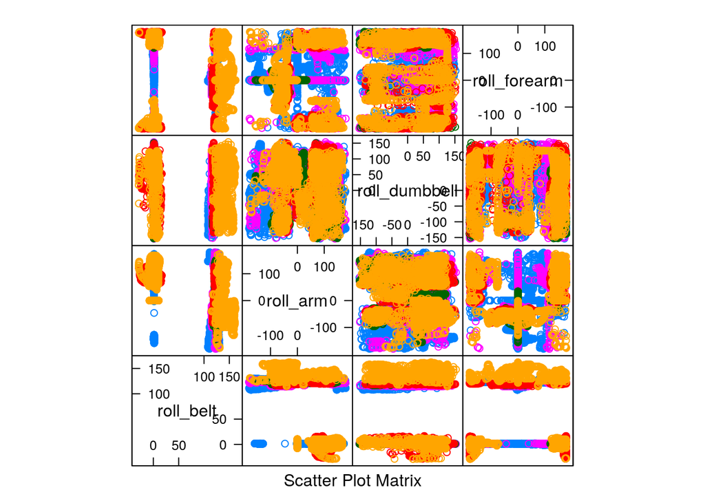

```r
# select only the columns that start with 'roll'
testingAC  <- testing[c(grep("^roll",names(training)))]
featurePlot(x=trainingAC[,1:4],y=training$classe,plot="pairs")
```

```r
fit1<-train(classe ~ ., data=trainingAC,model="lm",verbose=F,na.action = na.omit)
fit1$finalModel
```

```
##
## Call:
##  randomForest(x = x, y = y, mtry = param$mtry, model = "lm", verbose = ..2)
##                Type of random forest: classification
##                      Number of trees: 500
## No. of variables tried at each split: 2
##
##         OOB estimate of  error rate: 7.84%
## Confusion matrix:
##      A    B    C    D    E class.error
## A 5313   81  104   61   21  0.04784946
## B  116 3375  176  106   24  0.11114037
## C   77  100 3064  141   40  0.10461718
## D   57   70  175 2882   32  0.10385572
## E   11   39   58   50 3449  0.04380371
```

```r
pred1<-predict(fit1,testingAC)
table(pred1)
```

```
## pred1
## A B C D E
## 7 8 1 1 3
```

Therefore, 7 cases were chosen as classe A, 8 as B and so on.

```r
fit2<-train(classe ~ ., data=trainingAC,model="rpart",na.action = na.omit,
            trControl=trainControl(method="cv",number=3) )
fit2$finalModel
```

```
##
## Call:
##  randomForest(x = x, y = y, mtry = param$mtry, model = "rpart")
##                Type of random forest: classification
##                      Number of trees: 500
## No. of variables tried at each split: 2
##
##         OOB estimate of  error rate: 7.91%
## Confusion matrix:
##      A    B    C    D    E class.error
## A 5310   80  109   63   18  0.04838710
## B  117 3382  175  101   22  0.10929681
## C   80  107 3062  138   35  0.10520164
## D   57   76  175 2873   35  0.10665423
## E   12   37   63   52 3443  0.04546715
```

```r
pred2<-predict(fit2,testingAC)
table(pred2)
```

```
## pred2
## A B C D E
## 6 8 2 1 3
```

#### References

Improve Your Model Performance using Cross Validation (in Python and R). Analytics Vidhya. https://www.analyticsvidhya.com/blog/2018/05/improve-model-performance-cross-validation-in-python-r/